# Large Seedling PIRI Linear Regression

Kathleen Stutzman

2024-01-10

Libraries:

```r
# libraries -------------------
library(dplyr)
library(tidyverse)
library(ggplot2)
library(GGally)
library(glmmTMB)
library(TMB)
library(emmeans)
library(DHARMa)
library(lmtest)
```

Set working directory

```r
knitr::opts_knit$set(root.dir = '/Users/user/Desktop/Data/Regen_RProj/')
```

Functions:

```r
# functions -------------------
```

Source large seedling data:

```r
source("Scripts/LS_Import.R")
```

Pivot wider to create dataframe where each row is for one plot and has total details for each species group

```r
ls_merge2 <- ls_merge %>%
  select(Plot_No, Region, Treat_Type, Site, Species_Groups, Total) #this is dropiing browse and stump sprout data

ls_merge2 <- ls_merge2 %>%
  pivot_wider(names_from = Species_Groups, values_from = Total)
```

Import time since data and add it to the large seedling dataset

```r
time_since <- read_csv("CleanData/Treat_Year_Data.csv")

ls_merge3 <- merge(ls_merge2, time_since, by = 'Site')
#log transform time from treatment data
ls_merge3$l.TFT <- log(ls_merge3$Time_from_Treat)
```

Run the ‘Add_BA’ script and merge with dataset:

```r
source("Scripts/Add_BA.R")

# merge with ls dataset -------------------
ls_merge4 <- merge(ls_merge3, prism_BA, by = "Plot_No")
```

Run ‘Ground_Data.R’ script and add it to large seedling dataset:

```r
source("Scripts/Ground_Data.R")

# merge with ls dataset -------------------
ls_merge5 <- merge(ls_merge4, ground3, by = "Plot_No")
```

Source and add veg data

```r
source("Scripts/Veg_Data.R")

# merge with ls dataset
ls.all <- merge(ls_merge5, veg3, by = "Plot_No")

rm(ls_merge5,
   ls_merge2,
   ls_merge3,
   ls_merge4)
```

The large seedling count data is taken in 10m<sup>2</sup> plots; basal area is measured in hectares; veg and soil data is taken in 1m<sup>2</sup> plots.

Large seedling data will be converted into 1m<sup>2</sup> plots in order to compare across and reduce the amount of scales of data collection to two: 1m<sup>2</sup> plots and per hectare observations.

```r
ls.all$PIRI.1m <- ls.all$PIRI/10
ls.all$SO.1m <- ls.all$Shrub_Oak/10
ls.all$Other.1m <- ls.all$Other/10
```

Create log transformed categories for newly added variables, then select for just the desired variables:

```r
ls.all$l.PIRI1 <- log(ls.all$PIRI.1m + 1)
ls.all$l.SO1 <- log(ls.all$SO.1m + 1)
ls.all$l.other1 <- log(ls.all$Other.1m + 1)

ls.all2 <- ls.all %>%
  select(Treat_Type, Region, Site, Plot_No, PIRI, PIRI.1m, l.PIRI1, Shrub_Oak, SO.1m, l.SO1, Other, Other.1m, l.other1, Time_from_Treat, l.TFT, BA_HA, l.BA_HA, PIRI.BA_HA, l.BA_piri, Mineral_Soil, l.Mineral, Litter_Duff, avgLD, avgLD_l, Veg_Total, l.Veg_Total) %>%
  arrange(Treat_Type)
```

Select just for numerical vs log and then look at paired plots:

```r
#not transformed
ls.num <- ls.all2 %>%
  select(PIRI, Shrub_Oak, Other, Time_from_Treat, BA_HA, PIRI.BA_HA, Mineral_Soil, avgLD, Veg_Total, Treat_Type)

ggpairs(ls.num)
ggpairs(ls.num, aes(color = Treat_Type))


#log transformed
ls.numl <- ls.all2 %>%
  select(l.PIRI, l.SO, l.other, l.TFT, l.BA_HA, l.BA_piri, l.Mineral, avgLD_l, l.Veg_Total, Treat_Type)

ggpairs(ls.numl)
ggpairs(ls.numl, aes(color = Treat_Type))

rm(ls.num,
   ls.numl)
```

[output not shown]

# The above script a data naming conventions are the same as in the LS_GLMM script

Full dataset is called ls.all2

Starting first with model analysis without treatment type:

```r
ls.m1 <- glmmTMB(PIRI.1m ~ l.SO1 + l.other1 + l.BA_HA + l.BA_piri + l.Mineral + avgLD_l + l.Veg_Total + offset(l.TFT) + (1|Site/Plot_No),
                 data = ls.all2,
                 family = poisson)
AIC(ls.m1) #98.5
```

```
## [1] 98.45309
```

```r
# gives warning about non-integer values (as i've reduced the counts (/10) to get them to the 1m2 ) - if BA isn't important, I could try again with no BA in dataset and keep 10m2 observations ....
summary(ls.m1)
```

```
##  Family: poisson  ( log )
## Formula:
## PIRI.1m ~ l.SO1 + l.other1 + l.BA_HA + l.BA_piri + l.Mineral +
##     avgLD_l + l.Veg_Total + offset(l.TFT) + (1 | Site/Plot_No)
## Data: ls.all2
##
##      AIC      BIC   logLik deviance df.resid
##     98.5    140.6    -39.2     78.5      488
##
## Random effects:
##
## Conditional model:
##  Groups       Name        Variance  Std.Dev.
##  Plot_No:Site (Intercept) 2.561e-09 5.061e-05
##  Site         (Intercept) 6.410e+00 2.532e+00
## Number of obs: 498, groups:  Plot_No:Site, 498; Site, 47
##
## Conditional model:
##             Estimate Std. Error z value Pr(>|z|)
## (Intercept) -4.69499    3.33513  -1.408    0.159
## l.SO1       -1.13705    1.00373  -1.133    0.257
## l.other1    -0.21927    1.53411  -0.143    0.886
## l.BA_HA     -0.28410    0.59909  -0.474    0.635
## l.BA_piri   -0.38588    0.60304  -0.640    0.522
## l.Mineral    0.08863    0.34845   0.254    0.799
## avgLD_l     -0.08137    0.87393  -0.093    0.926
## l.Veg_Total -0.33215    0.65895  -0.504    0.614
```

```r
ls.m2 <- glmmTMB(PIRI.1m ~ l.SO1 + l.other1 + l.BA_HA + l.Mineral + avgLD_l + l.Veg_Total + offset(l.TFT) + (1|Site/Plot_No),
                 data = ls.all2,
                 family = poisson)
AIC(ls.m2) #96.8
```

```
## [1] 96.83059
```

```r
lrtest(ls.m1, ls.m2) #p = 0.5
```

```
## Likelihood ratio test
##
## Model 1: PIRI.1m ~ l.SO1 + l.other1 + l.BA_HA + l.BA_piri + l.Mineral +
##     avgLD_l + l.Veg_Total + offset(l.TFT) + (1 | Site/Plot_No)
## Model 2: PIRI.1m ~ l.SO1 + l.other1 + l.BA_HA + l.Mineral + avgLD_l +
##     l.Veg_Total + offset(l.TFT) + (1 | Site/Plot_No)
##   #Df  LogLik Df  Chisq Pr(>Chisq)
## 1  10 -39.227
## 2   9 -39.415 -1 0.3775     0.5389
```

```r
ls.m3 <- glmmTMB(PIRI.1m ~ l.SO1 + l.other1 + l.Mineral + avgLD_l + l.Veg_Total + offset(l.TFT) + (1|Site/Plot_No),
                 data = ls.all2,
                 family = poisson)
AIC(ls.m3) #96.0
```

```
## [1] 96.00496
```

```r
lrtest(ls.m2, ls.m3) # p = 0.3
```

```
## Likelihood ratio test
##
## Model 1: PIRI.1m ~ l.SO1 + l.other1 + l.BA_HA + l.Mineral + avgLD_l +
##     l.Veg_Total + offset(l.TFT) + (1 | Site/Plot_No)
## Model 2: PIRI.1m ~ l.SO1 + l.other1 + l.Mineral + avgLD_l + l.Veg_Total +
##     offset(l.TFT) + (1 | Site/Plot_No)
##   #Df  LogLik Df  Chisq Pr(>Chisq)
## 1   9 -39.415
## 2   8 -40.002 -1 1.1744     0.2785
```

```r
rm(ls.m1, ls.m2, ls.m3)

ls.m11a <- glmmTMB(PIRI.1m ~ avgLD_l + offset(l.TFT) + (1|Site/Plot_No),
                 data = ls.all2,
                 family = poisson)
AIC(ls.m11a) #AIC = 89.3, was just interested to see the AIC of this model vs. ls at 10m2 observations
```

```
## [1] 89.37025
```

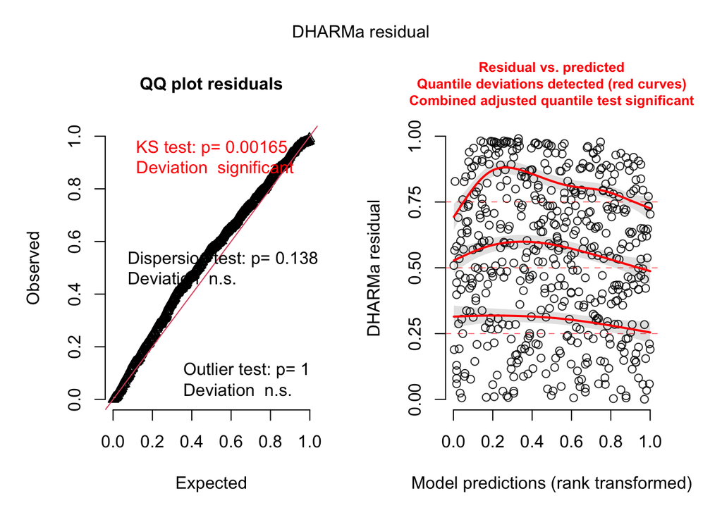

```r
#i'm just interested to see model fit on this 1m model
ls.m11a_sr <-  simulateResiduals(ls.m11a, n = 1000, plot = T) #fails very much so
```

Basal area doesn’t seem important, so I’m going to go back to the 10m<sup>2</sup> and 1m<sup>2</sup> scales and lose per hectare observations. I’ll need to rework the dataset

Revised data set with LS observations at 10m<sup>2</sup> scale; this means no non-interger values for the poisson distro

```r
ls.all3 <- ls.all

ls.all3$l.PIRI <- log(ls.all3$PIRI + 1)
ls.all3$l.SO <- log(ls.all3$Shrub_Oak + 1)
ls.all3$l.other <- log(ls.all3$Other + 1)

ls.all3 <- ls.all3 %>%
  select(Treat_Type, Region, Site, Plot_No, PIRI, l.PIRI, Shrub_Oak, l.SO, Other, l.other, Time_from_Treat, l.TFT, BA_HA, l.BA_HA, PIRI.BA_HA, l.BA_piri, Mineral_Soil, l.Mineral, Litter_Duff, avgLD, avgLD_l, Veg_Total, l.Veg_Total) %>%
  arrange(Treat_Type)
```

Begin modeling again:

```r
#double checking about basal area variables, even though this is at 3 scales

ls.m4 <- glmmTMB(PIRI ~ l.SO + l.other + l.BA_HA + l.BA_piri + l.Mineral + avgLD_l + l.Veg_Total + offset(l.TFT) + (1|Site/Plot_No),
                 data = ls.all3,
                 family = poisson)
AIC(ls.m4) #AIC is 291

#test piri ba
ls.m5 <- glmmTMB(PIRI ~ l.SO + l.other + l.BA_HA + l.Mineral + avgLD_l + l.Veg_Total + offset(l.TFT) + (1|Site/Plot_No),
                 data = ls.all3,
                 family = poisson)
AIC(ls.m5) #289.2

lrtest(ls.m4, ls.m5) #p = 0.7

#test ba
ls.m6 <- glmmTMB(PIRI ~ l.SO + l.other + l.Mineral + avgLD_l + l.Veg_Total + offset(l.TFT) + (1|Site/Plot_No),
                 data = ls.all3,
                 family = poisson)
AIC(ls.m6) #287.3

lrtest(ls.m5, ls.m6) #p=0.8

#test mineral soil
ls.m7 <- glmmTMB(PIRI ~ l.SO + l.other + avgLD_l + l.Veg_Total + offset(l.TFT) + (1|Site/Plot_No),
                 data = ls.all3,
                 family = poisson)
AIC(ls.m7) #285.3

lrtest(ls.m6, ls.m7) # p = 0.8

#test litter depth
ls.m8 <- glmmTMB(PIRI ~ l.SO + l.other + l.Veg_Total + offset(l.TFT) + (1|Site/Plot_No),
                 data = ls.all3,
                 family = poisson)
AIC(ls.m8) #289.5

lrtest(ls.m7, ls.m8) # p = 0.01, keep avg LD

#return avg ld, test other
ls.m9 <- glmmTMB(PIRI ~ l.SO + avgLD_l + l.Veg_Total + offset(l.TFT) + (1|Site/Plot_No),
                 data = ls.all3,
                 family = poisson)
AIC(ls.m9) #285.1

lrtest(ls.m7, ls.m9) #p = 0.2

# test shrub oak
ls.m10 <- glmmTMB(PIRI ~ avgLD_l + l.Veg_Total + offset(l.TFT) + (1|Site/Plot_No),
                 data = ls.all3,
                 family = poisson)
AIC(ls.m10) #285.2

lrtest(ls.m10, ls.m9) #p = 0.1

#test veg cover ------ seems like this is the best model
ls.m11 <- glmmTMB(PIRI ~ avgLD_l + offset(l.TFT) + (1|Site/Plot_No),
                 data = ls.all3,
                 family = poisson)
AIC(ls.m11) # p = 283.2

lrtest(ls.m10, ls.m11) # p = 0.97

rm(ls.m4, ls.m5, ls.m6, ls.m7, ls.m8, ls.m9, ls.m10)
```

Now to test model fit:

```r
ls.m11_sr <- simulateResiduals(ls.m11, n = 1000, plot = TRUE) #doesn't pass ks
testResiduals(ls.m11_sr)
testZeroInflation(ls.m11_sr)

# I wonder if I added treat type, if the model would pass
ls.m12 <- glmmTMB(PIRI ~ Treat_Type + avgLD_l + offset(l.TFT) + (1|Site/Plot_No),
                 data = ls.all3,
                 family = poisson)
AIC(ls.m12) #284.6

lrtest(ls.m12, ls.m11) #says treat type isn't important

ls.m12_sr <- simulateResiduals(ls.m12, n = 1000, plot = T) #looks better, still not perfect

testResiduals(ls.m12_sr) #passes
testZeroInflation(ls.m12_sr) #passes
testQuantiles(ls.m12_sr)

#going to test a model with more variables (and not treat type), to see if that fits better


ls.m10_sr <- simulateResiduals(ls.m10, n = 1000, plot = T)
#tests on model 9 failed & on 10
```

Models without treatment type failed in model fit. Going to run variable elimination again, starting with models with treatment type

```r
ls.m13 <- glmmTMB(PIRI ~ Treat_Type + l.SO + l.other + l.BA_HA + l.BA_piri + l.Mineral + avgLD_l + l.Veg_Total + offset(l.TFT) + (1|Site/Plot_No),
                 data = ls.all3,
                 family = poisson)
AIC(ls.m13) #293.2
```

```
## [1] 293.1687
```

```r
ls.m14 <- glmmTMB(PIRI ~ Treat_Type + l.SO + l.other + l.BA_HA + l.Mineral + avgLD_l + l.Veg_Total + offset(l.TFT) + (1|Site/Plot_No),
                 data = ls.all3,
                 family = poisson)
AIC(ls.m14) #291.3
```

```
## [1] 291.3429
```

```r
ls.m15 <- glmmTMB(PIRI ~ Treat_Type + l.SO + l.other + l.Mineral + avgLD_l + l.Veg_Total + offset(l.TFT) + (1|Site/Plot_No),
                 data = ls.all3,
                 family = poisson)
AIC(ls.m15) #289.5
```

```
## [1] 289.4573
```

```r
ls.m16 <- glmmTMB(PIRI ~ Treat_Type + l.SO + l.other + avgLD_l + l.Veg_Total + offset(l.TFT) + (1|Site/Plot_No),
                 data = ls.all3,
                 family = poisson)
AIC(ls.m16) #287.5
```

```
## [1] 287.4731
```

```r
ls.m17 <- glmmTMB(PIRI ~ Treat_Type + l.SO + avgLD_l + l.Veg_Total + offset(l.TFT) + (1|Site/Plot_No),
                 data = ls.all3,
                 family = poisson)
AIC(ls.m17) #286.3
```

```
## [1] 286.315
```

```r
lrtest(ls.m13, ls.m14, ls.m15, ls.m16, ls.m17)
```

```
## Likelihood ratio test
##
## Model 1: PIRI ~ Treat_Type + l.SO + l.other + l.BA_HA + l.BA_piri + l.Mineral +
##     avgLD_l + l.Veg_Total + offset(l.TFT) + (1 | Site/Plot_No)
## Model 2: PIRI ~ Treat_Type + l.SO + l.other + l.BA_HA + l.Mineral + avgLD_l +
##     l.Veg_Total + offset(l.TFT) + (1 | Site/Plot_No)
## Model 3: PIRI ~ Treat_Type + l.SO + l.other + l.Mineral + avgLD_l + l.Veg_Total +
##     offset(l.TFT) + (1 | Site/Plot_No)
## Model 4: PIRI ~ Treat_Type + l.SO + l.other + avgLD_l + l.Veg_Total +
##     offset(l.TFT) + (1 | Site/Plot_No)
## Model 5: PIRI ~ Treat_Type + l.SO + avgLD_l + l.Veg_Total + offset(l.TFT) +
##     (1 | Site/Plot_No)
##   #Df  LogLik Df  Chisq Pr(>Chisq)
## 1  14 -132.58
## 2  13 -132.67 -1 0.1742     0.6764
## 3  12 -132.73 -1 0.1144     0.7352
## 4  11 -132.74 -1 0.0159     0.8998
## 5  10 -133.16 -1 0.8418     0.3589
```

```r
ls.m18 <- glmmTMB(PIRI ~ Treat_Type + avgLD_l + l.Veg_Total + offset(l.TFT) + (1|Site/Plot_No),
                 data = ls.all3,
                 family = poisson)
AIC(ls.m18) #286.6
```

```
## [1] 286.5651
```

```r
lrtest(ls.m17, ls.m18) #p = 0.13
```

```
## Likelihood ratio test
##
## Model 1: PIRI ~ Treat_Type + l.SO + avgLD_l + l.Veg_Total + offset(l.TFT) +
##     (1 | Site/Plot_No)
## Model 2: PIRI ~ Treat_Type + avgLD_l + l.Veg_Total + offset(l.TFT) + (1 |
##     Site/Plot_No)
##   #Df  LogLik Df  Chisq Pr(>Chisq)
## 1  10 -133.16
## 2   9 -134.28 -1 2.2502     0.1336
```

```r
ls.m19 <- glmmTMB(PIRI ~ Treat_Type + avgLD_l + offset(l.TFT) + (1|Site/Plot_No),
                 data = ls.all3,
                 family = poisson)
summary(ls.m19) #284.6
```

```
##  Family: poisson  ( log )
## Formula:
## PIRI ~ Treat_Type + avgLD_l + offset(l.TFT) + (1 | Site/Plot_No)
## Data: ls.all3
##
##      AIC      BIC   logLik deviance df.resid
##    284.6    318.3   -134.3    268.6      490
##
## Random effects:
##
## Conditional model:
##  Groups       Name        Variance Std.Dev.
##  Plot_No:Site (Intercept) 2.096    1.448
##  Site         (Intercept) 9.911    3.148
## Number of obs: 498, groups:  Plot_No:Site, 498; Site, 47
##
## Conditional model:
##                    Estimate Std. Error z value Pr(>|z|)
## (Intercept)         -8.7216     1.8797  -4.640 3.49e-06 ***
## Treat_TypeFallRx     2.8500     1.8888   1.509  0.13133
## Treat_TypeHarvest    5.7603     2.0508   2.809  0.00497 **
## Treat_TypeMowRx      2.1656     1.8477   1.172  0.24117
## Treat_TypeSpringRx   2.7379     2.1166   1.294  0.19582
## avgLD_l             -1.1665     0.5173  -2.255  0.02413 *
## ---
## Signif. codes:  0 '***' 0.001 '**' 0.01 '*' 0.05 '.' 0.1 ' ' 1
```

```r
lrtest(ls.m18, ls.m19) #0.98
```

```
## Likelihood ratio test
##
## Model 1: PIRI ~ Treat_Type + avgLD_l + l.Veg_Total + offset(l.TFT) + (1 |
##     Site/Plot_No)
## Model 2: PIRI ~ Treat_Type + avgLD_l + offset(l.TFT) + (1 | Site/Plot_No)
##   #Df  LogLik Df Chisq Pr(>Chisq)
## 1   9 -134.28
## 2   8 -134.28 -1 6e-04     0.9812
```

```r
ls.m20 <- glmmTMB(PIRI ~ Treat_Type + offset(l.TFT) + (1|Site/Plot_No),
                 data = ls.all3,
                 family = poisson)
AIC(ls.m20) #288
```

```
## [1] 288.0281
```

```r
lrtest(ls.m19, ls.m20) # p = 0.02
```

```
## Likelihood ratio test
##
## Model 1: PIRI ~ Treat_Type + avgLD_l + offset(l.TFT) + (1 | Site/Plot_No)
## Model 2: PIRI ~ Treat_Type + offset(l.TFT) + (1 | Site/Plot_No)
##   #Df  LogLik Df  Chisq Pr(>Chisq)
## 1   8 -134.28
## 2   7 -137.01 -1 5.4624    0.01943 *
## ---
## Signif. codes:  0 '***' 0.001 '**' 0.01 '*' 0.05 '.' 0.1 ' ' 1
```

```r
rm(ls.m13, ls.m14, ls.m15, ls.m16, ls.m17, ls.m18, ls.m20)
```

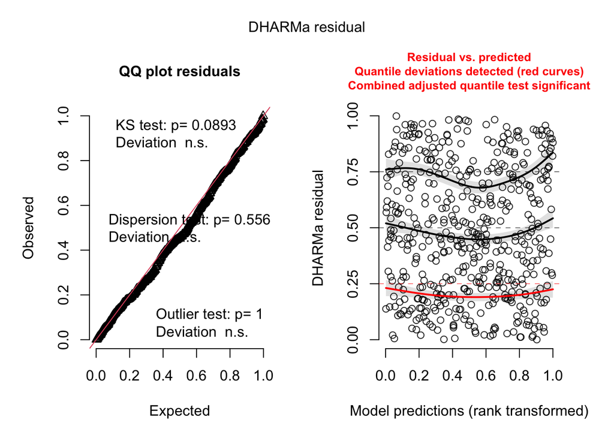

```r
ls.m19_sr <- simulateResiduals(ls.m19, n = 1000, plot = TRUE) #passes KS, quantile deviations fails, but it still could be an accepted model
```

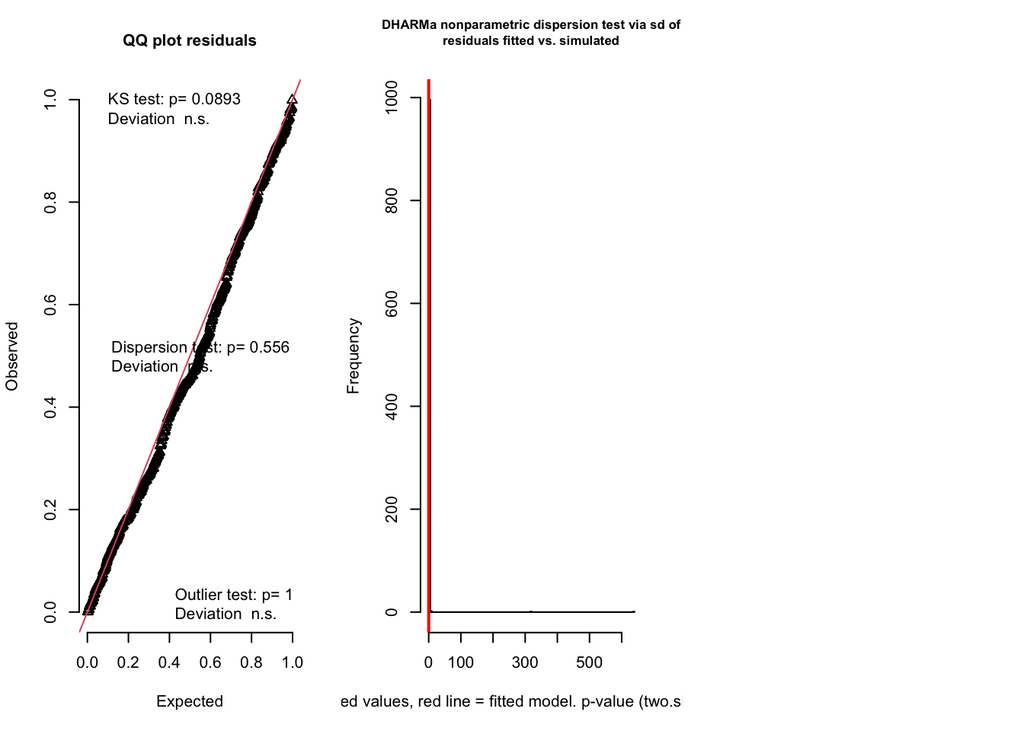

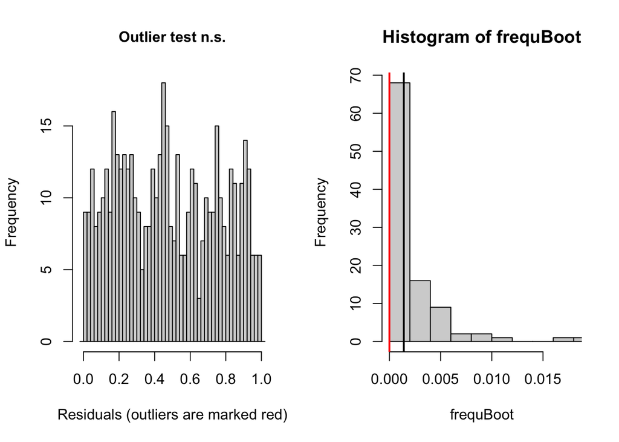

```
## $uniformity
##
##  Asymptotic one-sample Kolmogorov-Smirnov test
##
## data:  simulationOutput$scaledResiduals
## D = 0.055868, p-value = 0.0893
## alternative hypothesis: two-sided
##
##
## $dispersion
##
##  DHARMa nonparametric dispersion test via sd of residuals fitted vs.
##  simulated
##
## data:  simulationOutput
## dispersion = 1.6209e-05, p-value = 0.556
## alternative hypothesis: two.sided
##
##
## $outliers
##
##  DHARMa bootstrapped outlier test
##
## data:  simulationOutput
## outliers at both margin(s) = 0, observations = 498, p-value = 1
## alternative hypothesis: two.sided
##  percent confidence interval:
##  0.000000000 0.009086345
## sample estimates:
## outlier frequency (expected: 0.00140562248995984 )
##                                                  0
```

[output not shown]

```r
testResiduals(ls.m19_sr) #pases
```

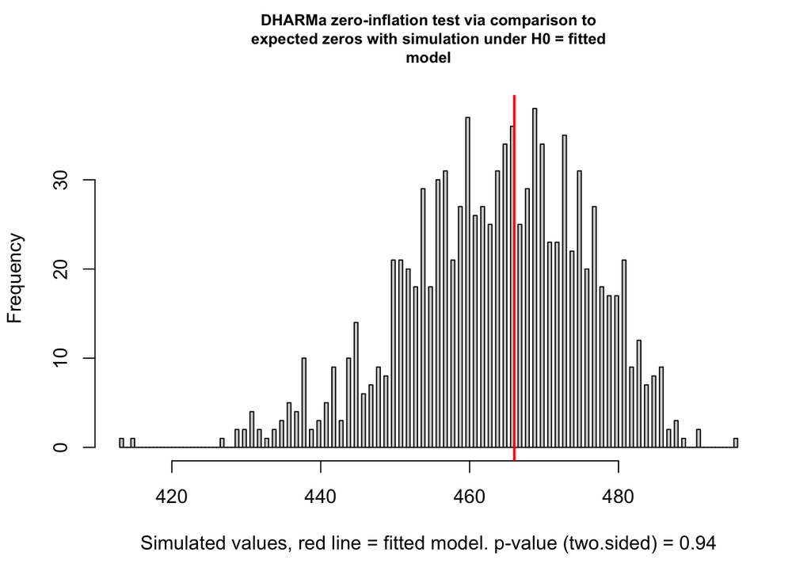

```
##
##  DHARMa zero-inflation test via comparison to expected zeros with
##  simulation under H0 = fitted model
##
## data:  simulationOutput
## ratioObsSim = 1.005, p-value = 0.94
## alternative hypothesis: two.sided
```

```r
testZeroInflation(ls.m19_sr) #passes
```

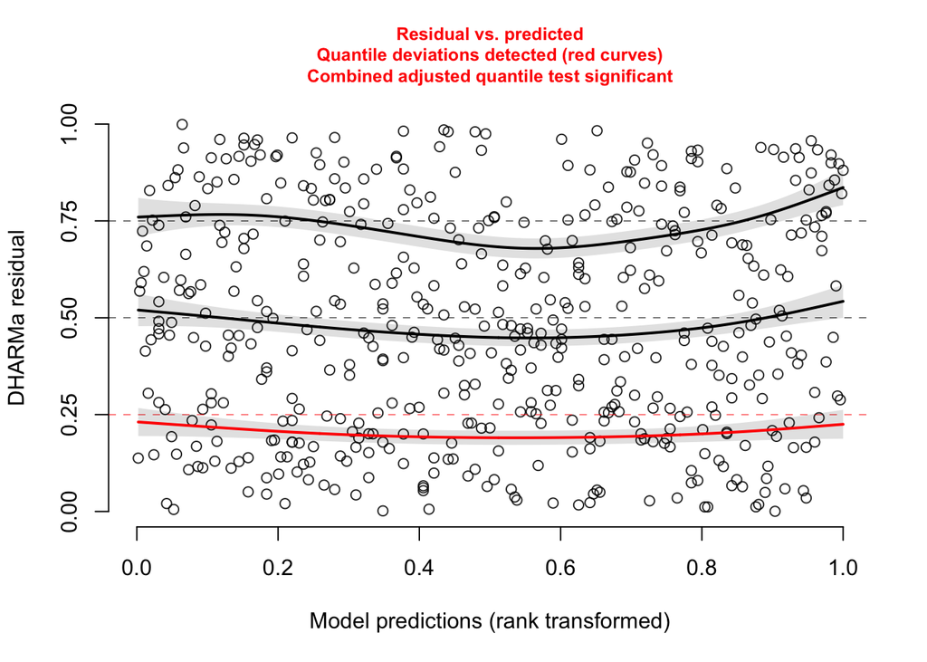

```
##
##  Test for location of quantiles via qgam
##
## data:  simulationOutput
## p-value = 0.00256
## alternative hypothesis: both
```

```r
testQuantiles(ls.m19_sr) #fails
```

Trying pairwise comparison of model fit:

```r
emmeans(ls.m19, specs = pairwise ~ Treat_Type, adjust = 'Tukey', type = 'response')
```

```
## $emmeans
##  Treat_Type     rate       SE  df asymp.LCL asymp.UCL
##  Control    0.000168 0.000292 Inf  5.63e-06   0.00503
##  FallRx     0.002912 0.004627 Inf  1.29e-04   0.06559
##  Harvest    0.053471 0.089469 Inf  2.01e-03   1.42029
##  MowRx      0.001469 0.002266 Inf  7.14e-05   0.03022
##  SpringRx   0.002603 0.004432 Inf  9.25e-05   0.07322
##
## Confidence level used: 0.95
## Intervals are back-transformed from the log scale
##
## $contrasts
##  contrast              ratio       SE  df null z.ratio p.value
##  Control / FallRx    0.05785  0.10926 Inf    1  -1.509  0.5566
##  Control / Harvest   0.00315  0.00646 Inf    1  -2.809  0.0399
##  Control / MowRx     0.11468  0.21190 Inf    1  -1.172  0.7674
##  Control / SpringRx  0.06471  0.13696 Inf    1  -1.294  0.6952
##  FallRx / Harvest    0.05446  0.10554 Inf    1  -1.502  0.5613
##  FallRx / MowRx      1.98261  3.42698 Inf    1   0.396  0.9948
##  FallRx / SpringRx   1.11861  2.24433 Inf    1   0.056  1.0000
##  Harvest / MowRx    36.40752 69.35922 Inf    1   1.887  0.3243
##  Harvest / SpringRx 20.54164 43.83726 Inf    1   1.416  0.6171
##  MowRx / SpringRx    0.56421  1.10087 Inf    1  -0.293  0.9984
##
## P value adjustment: tukey method for comparing a family of 5 estimates
## Tests are performed on the log scale
```

Control vs Harvest is the only significant different (p = 0.0399)

I’d like to see some graphs before I close out

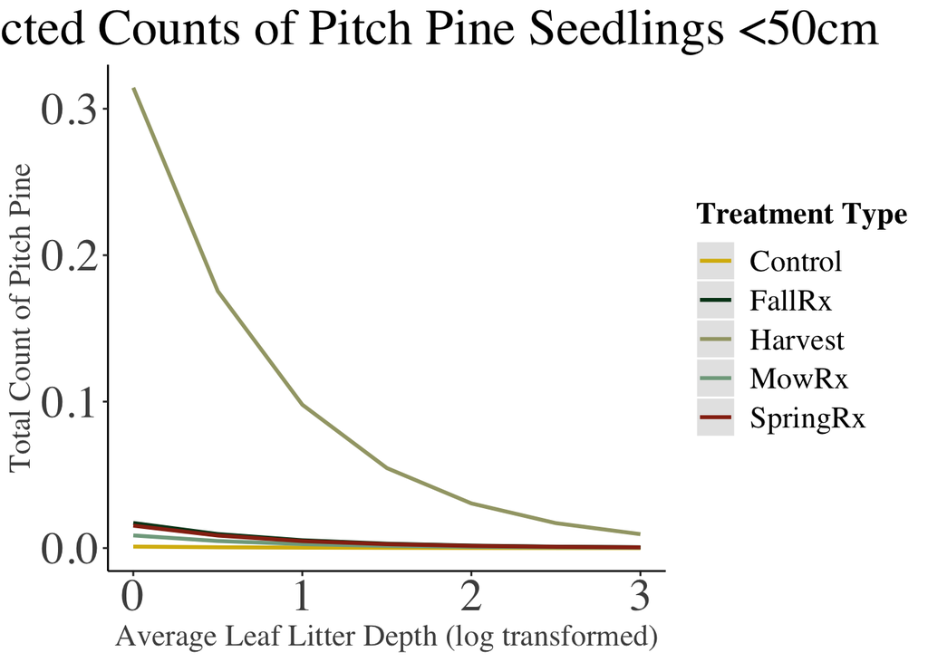

```r
library(sjPlot)
library(sjlabelled)
library(sjmisc)
set_theme(base = theme_classic(),
          theme.font = 'serif',
          axis.title.size = 1.5,
          axis.textsize.x = 1.5,
          axis.textsize.y = 1.5,
          title.size = 2.5,
          title.align = "center",
          legend.pos = "right",
          legend.size = 1.5,
          legend.title.size = 1.5,
          #legend.bordercol = "black",
          legend.item.size = .75)

# plot_model(ls.m19) #this is incidence rate ratios
#
# plot_model(ls.m19, type = "diag") #random vs normal quantiles
#
# plot_model(ls.m19, type = "re") #this plots random effects
#
# plot_model(ls.m19,
#            type = 'pred',
#            terms = 'Treat_Type') #plot marginal effects (i might have done this wrong)

# LS PIRI plot 1 ------------------- LD vs. TT
plot_model(ls.m19,
                       type = 'pred',
                       terms = c('avgLD_l', 'Treat_Type'),
                       axis.title = c("Average Leaf Litter Depth (log transformed)", "Total Count of Pitch Pine"),
                       title = "Predicted Counts of Pitch Pine Seedlings <50cm",
           legend.title = "Treatment Type",
           line.size = 1,
           value.offset = 'Treat_Type',
           ci.lvl = NA,
           colors = c("#D8B70A", "#02401B", "#A2A475", "#81A88D", "#972D15"))
```

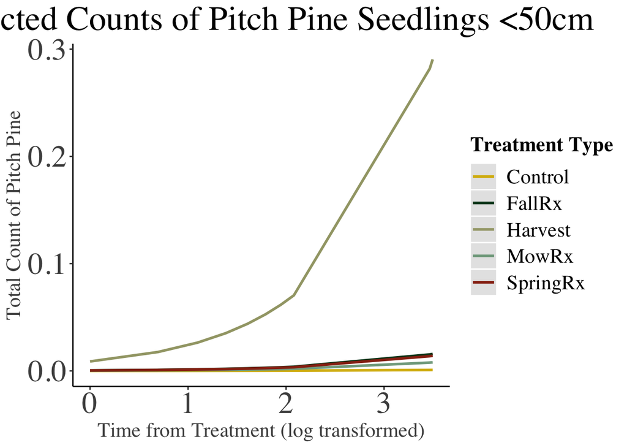

```r
# LS PIRI plot 2 ------------------- Time from Treatment vs TT
plot_model(ls.m19,
                       type = 'pred',
                       terms = c('l.TFT', 'Treat_Type'),
                       axis.title = c("Time from Treatment (log transformed)", "Total Count of Pitch Pine"),
                       title = "Predicted Counts of Pitch Pine Seedlings <50cm",
           legend.title = "Treatment Type",
           line.size = 1,
           value.offset = 'Treat_Type',
           ci.lvl = NA,
           colors = c("#D8B70A", "#02401B", "#A2A475", "#81A88D", "#972D15"))
```

Should I think about graphs where the offset is included?

Random slope for models?